# Cohen’s $d_z$ makes me dizzy because of measurement error

2023-02-17

$$\def\Pr{{\text{Pr}}}
\def\E{{\text{E}}}
\def\Var{{\text{Var}}}
\def\Cov{{\text{Cov}}}
\def\cor{{\text{cor}}}
\def\bm{\mathbf}
\def\bs{\boldsymbol}$$

Meta-analyses in education, psychology, and related fields rely heavily of Cohen’s $d$, or the standardized mean difference effect size, for describing the magnitude (and direction) of intervention effects. In these fields, Cohen’s $d$ is so pervasive that its application is nearly automatic (knee-jerk?) and analysts rarely question its utility or consider alternatives. Despite this, Cohen’s $d$ is theoretically challenging because the standardized mean difference metric does not have a singular definition. Rather, its definition depends on the choice of the standardizing variance used in the denominator.

Perhaps because use of Cohen’s $d$ is so under-scrutinized in practice, methodologists have spent many an afternoon blogging about this problem, including excellent discussions from [Jan Vanhove](https://janhove.github.io/reporting/2015/02/05/standardised-vs-unstandardised-es) (with [a sequel](https://janhove.github.io/design/2015/03/16/standardised-es-revisited)), [Jake Westfall](http://jakewestfall.org/blog/index.php/2016/03/25/five-different-cohens-d-statistics-for-within-subject-designs/), [Uri Simonsohn](http://datacolada.org/33), and [Pierre Dragicevic](https://transparentstatistics.org/2018/07/05/meanings-effect-size/), more formal discussions by [Thom Baguley](https://www.floppybunny.org/robin/web/virtualclassroom/stats/basics/articles/effect_size/effect_size_baguley_2009.pdf), and some very interesting work on alternative conceptualizations by [Tony Ades and colleagues](https://doi.org/10.1002/jrsm.1130). I can promise, dear reader, that the present blog post will not be nearly as cogent as these contributions—this is more about getting my own thoughts straight than making clear recommendations—and so *caveat lector* applies.

In this post, I’m going to mull over how measurement error and design decisions influence the metric definition of Cohen’s $d$ in simple within-group experimental designs. The distorting effects of measurement error has long been a source of concern within psychometric meta-analysis, a perspective associated with the work of [Frank Schmidt and Jack Hunter](https://methods.sagepub.com/book/methods-of-meta-analysis-3e), and measurement-error corrections are well developed and often applied in meta-analyses of correlations. Basic measurement-error corrections have also been described for Cohen’s $d$ from between-group designs (see recent work by [Brenton Wiernik and Jeff Dahlke](https://psyarxiv.com/9mpbn/)). However, I have literally never seen a meta-analytic application that applied these corrections and I have thus far been unable to locate work on such corrections specifically for effect sizes in within-group designs.[^1] So, time to muck about…

# Effect size definitions in within-group designs

In basic between-group designs, the only variances in the model are the within-group variances, so the choice of standardizing variance is limited to a) the singular population variance, assuming it is homogeneous across groups, b) the variance of one group, or c) the average of the variances in each group. In most applications, homogeneity is assumed (often without much reflection), version (a) of Cohen’s $d$ is calculated, and the meta-analyst can go along their merry way. For sake of succinctness, I’ll call this effect size $d_{b}$, with $b$ indicating that it is the usual version for basic between-group designs.

For within-group or repeated measures designs, the set of choices is more involved and includes a) standardizing by the across-participant variance in one condition (or both conditions, assuming homogeneity) or b) standardizing by the variance of the difference scores. The former approach is sometimes called $d_{av}$[^2], the latter is called $d_z$[^3]. The $d_{av}$ metric uses the same standardizing variance as the $d$ from a basic between-group design, and so results from both types of designs are, in principle, on the same metric.

In the context of meta-analysis, the comparability of $d_b$ and $d_{av}$ is useful when working with a set of studies that include both types of designs. On the other hand, in meta-analyses that consist solely of within-group or repeated measures designs, comparability with $d_b$ may be less of a priority and one might consider using $d_z$ for synthesis. Purely on a pragmatic level, $d_z$ might be attractive here because the only pieces of information needed to calculate it are the total sample size and the $t$ statistic (or $p$-value) from the comparison between conditions. In contrast, calculating $d_{av}$ also requires the between-participant standard deviations from one or both groups, which primary studies which might not always report.

Going in to this exercise, I had the notion that measurement error would affect $d_z$ to a greater degree than $d_{av}$, since $d_z$ involves difference scores and difference scores get hit by measurement error twice. Does this intuition hold up? Let me try to formalize things a bit.

# A within-group design with measurement error

Suppose we have a within-group design involving two conditions, where participants are assessed on $K$ trials under each condition. Let $Y_{ijk}$ denote the outcome from trial $k$ for participant $j$ under condition $i$, for $i = 1,2$, $j = 1,...,N$, and $k = 1,...,K$. A basic model for this set-up is
$$Y_{ijk} = \mu_i + u_{ij} + e_{ijk}$$
where $u_{1j}$ and $u_{2j}$ are participant-specific errors in the true scores under each condition and $e_{ijk}$ are measurement errors. For simplicity, I will assume that:

- the true-score variance is equal across conditions, with $\Var(u_{ij}) = \sigma^2$ for $i = 1,2$,
- the true scores are correlated across conditions, $\cor(u_{1j}, u_{2j}) = \rho$, and
- measurement errors are uncorrelated and have homogeneous variance across conditions, with $\Var(e_{ijk}) = \psi^2$.

Let $\phi = \sigma^2 / (\sigma^2 + \psi^2)$ denote the reliability (intra-class correlation) of a single observed score. Note that we can write $\psi^2$ in terms of the reliability and true-score variance as $\psi^2 = \sigma^2 \times \frac{1 - \phi}{\phi}$.

Under this model, there are several different standardized mean difference metrics that we could consider. Since measurement reliability might vary from study to study, it would make sense to define the metric in terms of true score variances alone, as
$$\delta_{av} = \frac{\mu_2 - \mu_1}{\sigma}$$
or in terms of the variance of the difference in true scores, as
$$\delta_z = \frac{\mu_2 - \mu_1}{\sigma \sqrt{2(1 - \rho)}}.$$
However, we don’t directly observe the true scores, and we can’t estimate their variance unless we have information about score reliabilities. Thus, meta-analysts will usually calculate effect sizes in terms of *observed* scores that include measurement error.

Suppose that the analysis is conducted by taking the average of the $K$ trials for each participant under each condition, $\bar{Y}_{ij} = \frac{1}{K} \sum_{k=1}^K Y_{ijk}$, and conducting the analysis using these mean scores. The variance of the mean scores is
$$\Var(\bar{Y}_{ij}) = \sigma^2 \left(1 + \frac{1 - \phi}{\phi K}\right),$$
so we can define the observed-score standardized mean difference using raw score standardization as
$$\tilde\delta_{av} = \frac{\mu_2 - \mu_1}{\sigma \sqrt{1 + \frac{1 -
\phi}{\phi K}}} = \frac{1}{\sqrt{1 + \frac{1 - \phi}{\phi K}}} \times
\delta_{av}.$$
From this expression, we can see that measurement error attenuates the true-score effect size because the multiplier term is always going to be less than one.

Similarly, the variance of the observed difference scores is
$$\Var(\bar{Y}_{2j} - \bar{Y}_{1j}) =2 \sigma^2 \left(1 - \rho + \frac{1 -
\phi}{\phi K}\right),$$
so we can define the observed-score standardized mean difference using change score standardization as
$$\tilde\delta_z = \frac{\mu_2 - \mu_1}{\sigma \sqrt{2 \left(1 - \rho +
\frac{1 - \phi}{\phi K}\right)}} = \sqrt{\frac{1 - \rho}{1 - \rho +
\frac{1 - \phi}{\phi K}}} \times \delta_z.$$
Again, we can see that measurement error attenuates the true-score effect size because the multiplier term is always going to be less than one. However, unlike with $d_{av}$, the attenuation factor here depends on $\rho$ in addition to $\phi$ and $K$. This additional term in the correction factor is one indication that $d_z$ might be less desirable for meta-analysis. Correcting $d_z$ for the distortion from measurement error would require estimates of both the true-score correlation and the reliability of the scores, whereas correcting $d_{av}$ would require only the latter.

# Meta-analysis

The relationships between the true-score effect sizes and the analogous observed score effect sizes starts to be a problem when we consider a meta-analysis that includes multiple studies. Primary studies will often use different instruments and procedures for measuring outcomes (necessitating the use of some standardized effect size), and those differences in instruments and procedures might come along with differences in score reliability as well as variation in the number of trials collected per condition (and plenty of other things, such as sample size, participant characteristics, etc.). Procedural heterogeneity like this creates two potential challenges for meta-analysis: bias in average effect sizes and extra heterogeneity in the distribution of effect sizes. Both could make findings from a meta-analysis more difficult to interpret.

To illustrate, let’s now imagine that the parameters of the within-group study design, $\delta_{av}$ or $\delta_z$, $\rho$, $\phi$, and $K$ are random variables, drawn from the distribution of parameters across a population of hypothetical studies.

## A model for $\delta_{av}$

Let’s first consider $\delta_{av}$ and assume that it follows a random effects model, with
$$\delta_{av} \sim N\left(\mu, \tau^2\right).$$
Let’s also assume that the remaining parameters $\rho$, $\phi$, and $K$ are independent of $\delta_{av}$. These parameters determine the attenuation factor $A_{av} = \left(1 + \frac{1 - \phi}{\phi K}\right)^{-1/2}$, which relates the observed-score effect size parameter to the true score effect size parameter.

The bias of $\tilde\delta_{av}$ is therefore
$$\E\left(\tilde\delta_{av}\right) = \E\left(A_{av}\delta_{av}\right) =
\E(A_{av}) \times \mu.$$
Thus, under my very simplistic assumptions, a meta-analysis of observed score Cohen’s $d_{av}$ estimates will be biased (downward) for the overall average effect in the true-score distribution. You might find that undesirable, of course. On the other hand, bias might not be as a big a problem as it first seems. If all of the observed-score effect sizes are biased to an extent that’s unrelated to the true effects, then bias just stretches or compresses the scale of measurement, but doesn’t necessarily lead to interpretive problems. It’s like if you had a ruler that is half an inch too short, and you’re trying to compare the heights of different objects. As long as you use the same ruler, then you will still be able to determine which objects are bigger and which are smaller, and by how much, even if the measurements are off in an absolute sense.

To see what’s going on here, let’s consider some specific distributions for these measurement factors. First, let’s assume:

- $\rho \sim B(14, 6)$, so that $\E(\rho) = .7$ and $\Var(\rho) = 0.1^2$;
- $\phi \sim B(3, 5)$, so that $\E(\rho) = .0.375$ and $\Var(\rho) = 0.161^2$;
- $K \sim 1 + Pois(9)$, so $\E(K) = 10$ and $\Var(K) = 3^2$; and
- $\rho$, $\phi$, and $K$ are mutually independent and independent of $\delta_{av}$.

Below I simulate 50000 samples from these distributions and calculate $A_{av}$ and $A_z$.

```r
R <- 50000
rho <- rbeta(R, 14, 6)
phi <- rbeta(R, 3, 5)
K <- 1 + rpois(R, 9)
A_av <- 1 / sqrt(1 + (1 - phi) / (phi * K))
A_z <- 1 / sqrt(2 * (1 - rho + (1 - phi) / (phi * K)))
```

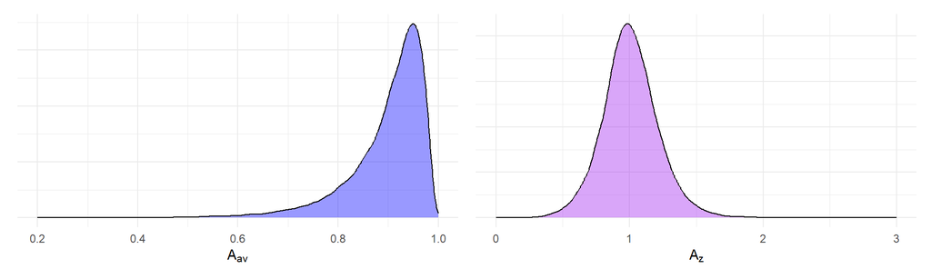

```r
library(ggplot2)
library(patchwork)

density_plot <- function(x, lab, col, limits) {
  ggplot(data.frame(x), aes(x)) +
    xlim(limits) +
    geom_density(alpha = 0.4, fill = col) +
    scale_y_continuous(labels = NULL) +
    theme_minimal() +
    labs(x = lab, y = NULL)
}

p_A_av <- density_plot(A_av, expression(A[av]),"blue", c(0.2,1))
p_A_z <- density_plot(A_z, expression(A[z]), "purple", c(0, 3))
p_A_av + p_A_z
```

The distribution of $A_{av}$ is mostly concentrated around the mean of $E(A_{av}) = 0.898$, with a squared coefficient of variation of $CV^2(A_{av}) = 0.007$. In contrast, the distribution of $A_{av}$ has a mean very close to one, $E(A_z) = 1.005$ but a squared coefficient of variation of $CV^2(A_z) = 0.043$, about 6 times larger! Thus, variation in measurement procedure induces much more extra heterogeneity into the distribution of $\tilde\delta_z$ than into $\tilde\delta_{av}$.

Now, one potential objection to this hypothetical scenario is that researchers do not choose the number of trials at random, without consideration for the other parameters of the study design. A more realistic assumption might be that researchers choose $K$ to ensure they achieve at least some threshold level of reliability for the observed scores. The reliability of the observed scores is $A_{av}^2$, so ensuring some threshold of reliability is equivalent to ensuring the square root of the threshold for $A_{av}$. Let’s suppose that researchers always ensure $A_{av} \geq 0.8$ so that reliability is always at least $0.64$. This leads to the following distributions for $A_{av}$ and $A_z$:

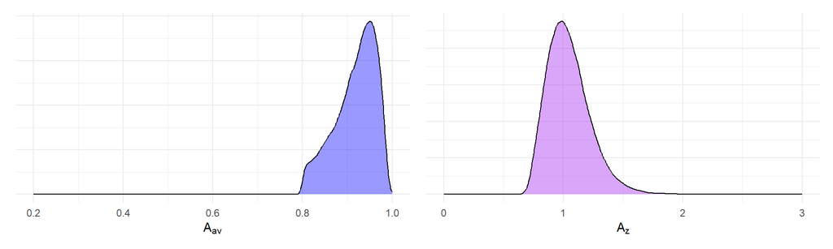

```r
A_av_trunc <- A_av[A_av >= 0.8]
A_z_trunc <- A_z[A_av >= 0.8]
p_A_av_trunc <- density_plot(A_av_trunc, expression(A[av]),"blue", c(0.2, 1))
p_A_z_trunc <- density_plot(A_z_trunc, expression(A[z]), "purple", c(0, 3))
p_A_av_trunc + p_A_z_trunc
```

The distribution of $A_{av}$ loses its left tail, so that its mean is $E(A_{av}|A_{av} \geq 0.8) = 0.918$ and its squared coefficient of variation is reduced to $CV^2(A_{av} | A_{av} \geq 0.8) = 0.002$. The distribution of $A_{av}$ now has a mean of $E(A_z | A_{av} \geq 0.8) = 1.044$ and a squared coefficient of variation of $CV^2(A_z | A_{av} \geq 0.8) = 0.03$, about 12 times larger than the squared coefficient of variation of $A_{av}$.

Under both of these scenarios, the observed-score $\tilde\delta_z$ is substantially more sensitive to heterogeneity of measurement procedures than is $\tilde\delta_{av}$. Based on this model and hypothetical example, it seems clear $\tilde\delta_{av}$ should be preferred over $\tilde\delta_z$ as a metric for meta-analyis.

## A model for $\delta_z$

Now, one might object to the above analysis because there’s a sense that it assumes that $\delta_{av}$ is the right answer. After all, the underlying effect size model is specified in terms of $\delta_{av}$, and the design parameters—including $\rho$ in particular—are treated as noise, uncorrelated with $\delta_{av}$. What happens to the observed-score metrics $\tilde\delta_z$ and $\tilde\delta_{av}$ if we instead start with a model specified in terms of $\delta_z$? Let’s see.

Assume that
$$\delta_z \sim N(\alpha, \omega^2)$$
and that the remaining parameters $\rho$, $\phi$, and $K$ are independent of $\delta_{av}$. Then the observed-score standardized mean difference using change score standardization can be written as $\tilde\delta_z = B_z \times \delta_z$, where
$$B_z = \sqrt{\frac{1 - \rho}{1 - \rho + \frac{1 - \phi}{\phi K}}}$$
and the observed-score standardized mean difference using raw score standardization can be written as $\tilde\delta_{av} = B_{av} \times \delta_z$, where
$$B_{av} = \frac{\sqrt{2}(1 - \rho)}{\sqrt{1 - \rho + \frac{1 - \phi}{\phi
K}}}.$$
The plots below show the distribution of $B_z$ and $B_{av}$ under the same scenarios considered above. First, the scenario where observed-score reliability is not controlled:

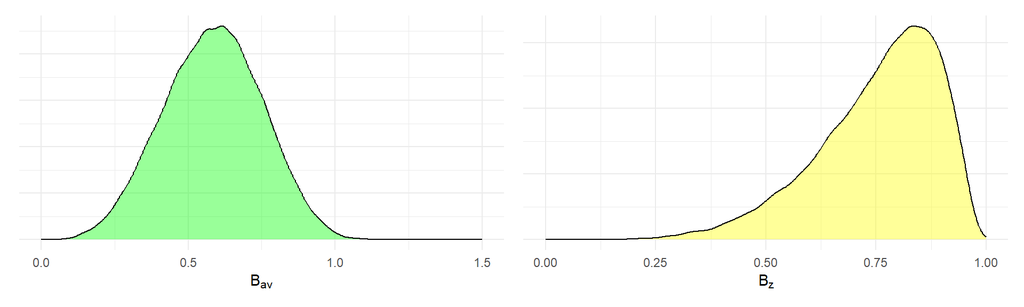

```r
B_z <- sqrt((1 - rho) / (1 - rho + (1 - phi) / (phi * K)))
B_av <- sqrt(2) * (1 - rho) / sqrt(1 - rho + (1 - phi) / (phi * K))

p_B_av <- density_plot(B_av, expression(B[av]),"green", c(0,1.5))
p_B_z <- density_plot(B_z, expression(B[z]), "yellow", c(0, 1))
p_B_av + p_B_z
```

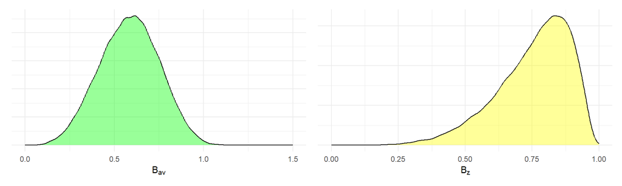

```r
B_z_trunc <- B_z[A_av >= 0.8]
B_av_trunc <- B_av[A_av >= 0.8]

p_B_av_trunc <- density_plot(B_av, expression(B[av]),"green", c(0,1.5))
p_B_z_trunc <- density_plot(B_z, expression(B[z]), "yellow", c(0, 1))
p_B_av_trunc + p_B_z_trunc
```

The table below reports the squared coefficients of variation for each of these multiplicative factors I have considered.

```r
library(dplyr)
dat <- tibble(A_av, A_z, B_av, B_z)

random_rel <-
  dat |>
  summarise(
    across(everything(), ~ var(.) / mean(.)^2),
    reliability = "random"
  )

controlled_rel <-
  dat |>
  filter(A_av >= 0.8) |>
  summarise(
    across(everything(), ~ var(.) / mean(.)^2),
    reliability = "at least 0.64"
  )

CVs <-
  bind_rows(random_rel, controlled_rel) |>
  mutate(
    A_ratio = A_z / A_av,
    B_ratio = B_av / B_z
  ) |>
  select(reliability, A_av, A_z, A_ratio, B_av, B_z, B_ratio)

knitr::kable(
  CVs,
  digits = c(0,4,4,1,4,4,1),
  title = "Squared coefficients of variation",
  col.names = c("Reliability","$A_{av}$","$A_z$","$A_z /A_{av}$", "$B_{av}$","$B_z$", "$B_{av} / B_z$"),
  escape = TRUE
)
```

| Reliability | $A_{av}$ | $A_z$ | $A_z /A_{av}$ | $B_{av}$ | $B_z$ | $B_{av} / B_z$ |
| --- | --- | --- | --- | --- | --- | --- |
| random | 0.0072 | 0.0435 | 6.1 | 0.0811 | 0.0329 | 2.5 |
| at least 0.64 | 0.0024 | 0.0297 | 12.1 | 0.0660 | 0.0188 | 3.5 |

[^1]: I would *love* to be corrected on both of these points. Please drop a comment or email me with suggested reading.
[^2]: When the standardizing variance is calculated using measurements from only one condition (i.e., the pre-test in a repeated measures design), this version of $d$ corresponds to `measure = "SMCR"`, the “stanardized mean change using raw score standardization” in `metafor::escalc`.
[^3]: This version of $d$ corresponds to `measure = "SMCC"`, the “stanardized mean change using change score standardization” in `metafor::escalc`.